# Assignment 7 - Repeated measure

Author

Aytan Pirverdiyeva

# 1 Introduction

This assignment will ask you to conduct a repeated measure analysis.

For that, you will first need to watch (and code along with) the following repeated measure video:

- repeated measure lecture: https://youtu.be/-ANqcQhB–A?si=7YeeYqDgcLsj5erW&t=4268 (starts at 01:11:08, watch till the end, about 50 min)
- repeated measure lab part 1: https://youtu.be/GY2e-9M5bFM?si=TIw5F4EF2m9Dx5uK (watch full video, ~1h 50 min)
- repeated measure lab part 2: https://youtu.be/F3vg89ymLeM?si=Zv-RPIdS8mig4EMb (watch full video, ~2h)
- The partial script for the video above is in our GitHub repository, 04-classcode, **03-11_repeatedmeasure_partial.qmd**.
- The data set for this exercise is in oir GitHub repository, 03-classcode, **wheat_nk_balkh_rm.csv**.

**AFTER watching the video and developing the code in class**, then start working on this HW assignment.

# 2 Instructions

- Create on your GitHub a repo named `06_rm`.
- Clone it to your computer, create the necessary subfolders.
- Move the script **03-11_repeatedmeasure_partial.qmd** into the `code` subfolder.
- Move this script into the `code` subfolder
- Move the **wheat_nk_balkh_rm.csv** data set into the `data` subfolder
- On this script, fill your name under the `title` section of the YAML

# 3 Goal of this assignment

The goal is this assignment is for you to **learn about and conduct a full repeated measure analysis**.

Once you finish coding along with the videos, answer the following questions.

#Setup and Wrangling

```r
library(tidyverse) # for data wrangling and plotting
library(car) # for Anova function
library(lme4)
library(broom) # for model residuals extraction
library(emmeans) # for model mean extraction
library(multcomp) # for pairwise comparison letter display
library(nlme) # for repeated measure correlation structures
```

#Read data

```r
rm_rcbd_df <- read_csv("../data/wheat_nk_balkh_rm.csv") %>%
  mutate(across(trt:splot, ~factor(.))) %>%
  mutate(fdap = factor(dap))
rm_rcbd_df
```

```
# A tibble: 144 × 10
   trt   block nrate_kgha krate_kgha trtname wplot splot yield_kgha   dap fdap
   <fct> <fct> <fct>      <fct>      <fct>   <fct> <fct>      <dbl> <dbl> <fct>
 1 1     1     0          0          0+0     101   101-1       5488   120 120
 2 1     1     0          0          0+0     101   101-1       5898   130 130
 3 1     1     0          0          0+0     101   101-1       6133   140 140
 4 1     1     0          0          0+0     101   101-1       6151   150 150
 5 2     1     0          30         0+30    102   102-1       4448   120 120
 6 2     1     0          30         0+30    102   102-1       4842   130 130
 7 2     1     0          30         0+30    102   102-1       5057   140 140
 8 2     1     0          30         0+30    102   102-1       5094   150 150
 9 3     1     0          60         0+60    103   103-1       7445   120 120
10 3     1     0          60         0+60    103   103-1       7901   130 130
# ℹ 134 more rows
```

#EDA

```r
summary(rm_rcbd_df)
```

```
      trt     block  nrate_kgha krate_kgha    trtname       wplot
 1      :16   1:36   0  :48     0 :48      0+0    :16   101    :12
 2      :16   2:36   100:48     30:48      0+30   :16   102    :12
 3      :16   3:36   200:48     60:48      0+60   :16   103    :12
 4      :16   4:36                         100+0  :16   201    :12
 5      :16                                100+30 :16   202    :12
 6      :16                                100+60 :16   203    :12
 (Other):48                                (Other):48   (Other):72
     splot       yield_kgha        dap         fdap
 101-1  :  4   Min.   :2795   Min.   :120.0   120:36
 101-2  :  4   1st Qu.:4788   1st Qu.:127.5   130:36
 101-3  :  4   Median :5280   Median :135.0   140:36
 102-1  :  4   Mean   :5233   Mean   :135.0   150:36
 102-2  :  4   3rd Qu.:5782   3rd Qu.:142.5
 102-3  :  4   Max.   :8121   Max.   :150.0
 (Other):120
```

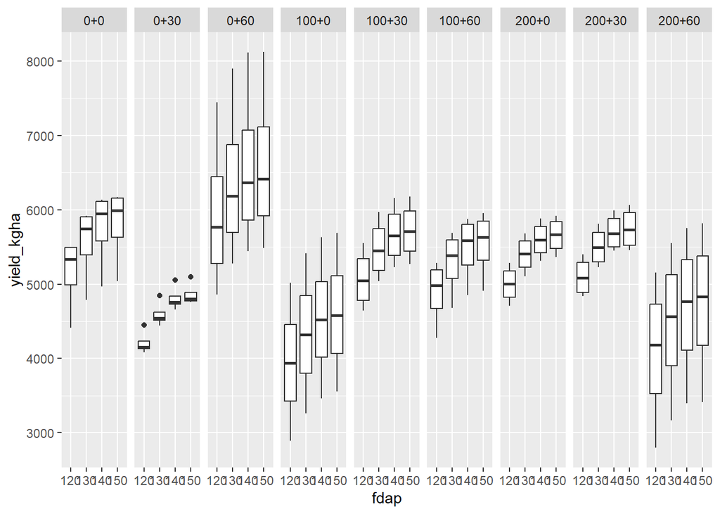

```r
ggplot(rm_rcbd_df, aes(x = fdap,
                       y = yield_kgha))+
  geom_boxplot() +
  facet_grid(.~trtname)
```

#Model 1 - Default

```r
options(contrasts = c("contr.sum", "contr.poly"))

mod1_default_lmer <-lmer(yield_kgha ~ krate_kgha*nrate_kgha*fdap +
                           (1|block/krate_kgha/nrate_kgha),
                         data = rm_rcbd_df
                           )
mod1_default_lmer
```

```
Linear mixed model fit by REML ['lmerMod']
Formula:
yield_kgha ~ krate_kgha * nrate_kgha * fdap + (1 | block/krate_kgha/nrate_kgha)
   Data: rm_rcbd_df
REML criterion at convergence: 1255.083
Random effects:
 Groups                      Name        Std.Dev.
 nrate_kgha:krate_kgha:block (Intercept) 581.94
 krate_kgha:block            (Intercept) 249.40
 block                       (Intercept) 216.69
 Residual                                 14.58
Number of obs: 144, groups:
nrate_kgha:krate_kgha:block, 36; krate_kgha:block, 12; block, 4
Fixed Effects:
                  (Intercept)                    krate_kgha1
                   5233.48611                     -125.27778
                  krate_kgha2                    nrate_kgha1
                    -27.77778                      286.53472
                  nrate_kgha2                          fdap1
                   -189.65278                     -412.15278
                        fdap2                          fdap3
                    -12.76389                      186.76389
      krate_kgha1:nrate_kgha1        krate_kgha2:nrate_kgha1
                    165.06944                     -873.86806
      krate_kgha1:nrate_kgha2        krate_kgha2:nrate_kgha2
                   -566.24306                      469.00694
            krate_kgha1:fdap1              krate_kgha2:fdap1
                      0.36111                        1.36111
            krate_kgha1:fdap2              krate_kgha2:fdap2
                     -3.44444                       -1.11111
            krate_kgha1:fdap3              krate_kgha2:fdap3
                     -0.88889                        1.61111
            nrate_kgha1:fdap1              nrate_kgha2:fdap1
                     -3.61806                        2.40278
            nrate_kgha1:fdap2              nrate_kgha2:fdap2
                      1.65972                       -0.06944
            nrate_kgha1:fdap3              nrate_kgha2:fdap3
                      3.21528                       -3.93056
krate_kgha1:nrate_kgha1:fdap1  krate_kgha2:nrate_kgha1:fdap1
                     -0.40278                        6.28472
krate_kgha1:nrate_kgha2:fdap1  krate_kgha2:nrate_kgha2:fdap1
                      3.07639                       -2.42361
krate_kgha1:nrate_kgha1:fdap2  krate_kgha2:nrate_kgha1:fdap2
                      3.48611                      -14.15972
krate_kgha1:nrate_kgha2:fdap2  krate_kgha2:nrate_kgha2:fdap2
                     -7.53472                        7.38194
krate_kgha1:nrate_kgha1:fdap3  krate_kgha2:nrate_kgha1:fdap3
                      1.59722                       -2.21528
krate_kgha1:nrate_kgha2:fdap3  krate_kgha2:nrate_kgha2:fdap3
                     -1.25694                        2.49306
```

```r
mod1_default <-lme(yield_kgha ~krate_kgha*nrate_kgha*fdap,
                   random = ~1 |block/krate_kgha/nrate_kgha,
                   data = rm_rcbd_df
                   )


mod1_default
```

```
Linear mixed-effects model fit by REML
  Data: rm_rcbd_df
  Log-restricted-likelihood: -627.5418
  Fixed: yield_kgha ~ krate_kgha * nrate_kgha * fdap
                  (Intercept)                   krate_kgha1
                5233.48611111                 -125.27777778
                  krate_kgha2                   nrate_kgha1
                 -27.77777778                  286.53472222
                  nrate_kgha2                         fdap1
                -189.65277778                 -412.15277778
                        fdap2                         fdap3
                 -12.76388889                  186.76388889
      krate_kgha1:nrate_kgha1       krate_kgha2:nrate_kgha1
                 165.06944444                 -873.86805556
      krate_kgha1:nrate_kgha2       krate_kgha2:nrate_kgha2
                -566.24305556                  469.00694444
            krate_kgha1:fdap1             krate_kgha2:fdap1
                   0.36111111                    1.36111111
            krate_kgha1:fdap2             krate_kgha2:fdap2
                  -3.44444444                   -1.11111111
            krate_kgha1:fdap3             krate_kgha2:fdap3
                  -0.88888889                    1.61111111
            nrate_kgha1:fdap1             nrate_kgha2:fdap1
                  -3.61805556                    2.40277778
            nrate_kgha1:fdap2             nrate_kgha2:fdap2
                   1.65972222                   -0.06944444
            nrate_kgha1:fdap3             nrate_kgha2:fdap3
                   3.21527778                   -3.93055556
krate_kgha1:nrate_kgha1:fdap1 krate_kgha2:nrate_kgha1:fdap1
                  -0.40277778                    6.28472222
krate_kgha1:nrate_kgha2:fdap1 krate_kgha2:nrate_kgha2:fdap1
                   3.07638889                   -2.42361111
krate_kgha1:nrate_kgha1:fdap2 krate_kgha2:nrate_kgha1:fdap2
                   3.48611111                  -14.15972222
krate_kgha1:nrate_kgha2:fdap2 krate_kgha2:nrate_kgha2:fdap2
                  -7.53472222                    7.38194444
krate_kgha1:nrate_kgha1:fdap3 krate_kgha2:nrate_kgha1:fdap3
                   1.59722222                   -2.21527778
krate_kgha1:nrate_kgha2:fdap3 krate_kgha2:nrate_kgha2:fdap3
                  -1.25694444                    2.49305556

Random effects:
 Formula: ~1 | block
        (Intercept)
StdDev:    216.6936

 Formula: ~1 | krate_kgha %in% block
        (Intercept)
StdDev:    249.3989

 Formula: ~1 | nrate_kgha %in% krate_kgha %in% block
        (Intercept) Residual
StdDev:    581.9363 14.57621

Number of Observations: 144
Number of Groups:
                                block                 krate_kgha %in% block
                                    4                                    12
nrate_kgha %in% krate_kgha %in% block
                                   36
```

#Check Anova

```r
Anova(mod1_default, type = 3)
```

```
Analysis of Deviance Table (Type III tests)

Response: yield_kgha
                                Chisq Df Pr(>Chisq)
(Intercept)                 1040.2045  1  < 2.2e-16 ***
krate_kgha                     0.9113  2    0.63404
nrate_kgha                     4.5157  2    0.10458
fdap                       44330.3542  3  < 2.2e-16 ***
krate_kgha:nrate_kgha         33.2786  4  1.047e-06 ***
krate_kgha:fdap                3.7507  6    0.71038
nrate_kgha:fdap                3.1727  6    0.78688
krate_kgha:nrate_kgha:fdap    19.8741 12    0.06951 .
---
Signif. codes:  0 '***' 0.001 '**' 0.01 '*' 0.05 '.' 0.1 ' ' 1
```

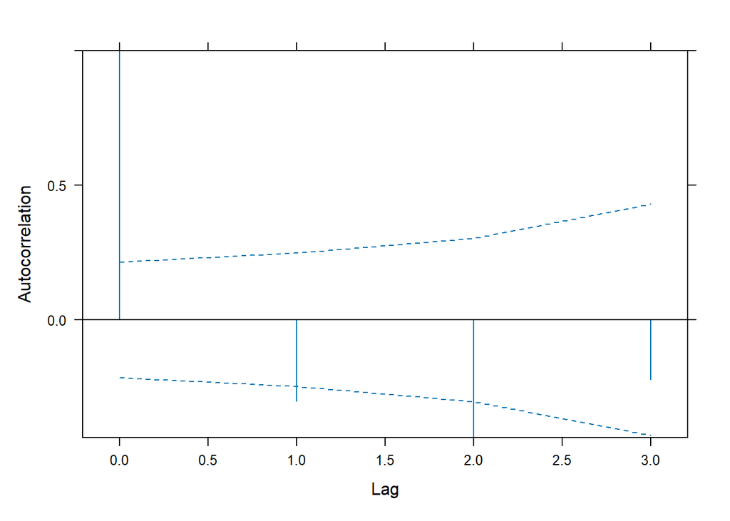

```r
ACF(mod1_default, resType = "n") %>%
  plot(alpha = 0.01)
```

# 4 Model 2 - Compound Symmetry

```r
mod2_cs <- lme(yield_kgha ~krate_kgha*nrate_kgha*fdap,
                   random = ~1 |block/krate_kgha/nrate_kgha,
                   correlation = corCompSymm(form = ~dap),
                   data = rm_rcbd_df
                   )

mod2_cs
```

```
Linear mixed-effects model fit by REML
  Data: rm_rcbd_df
  Log-restricted-likelihood: -627.5418
  Fixed: yield_kgha ~ krate_kgha * nrate_kgha * fdap
                  (Intercept)                   krate_kgha1
                5233.48611111                 -125.27777778
                  krate_kgha2                   nrate_kgha1
                 -27.77777778                  286.53472222
                  nrate_kgha2                         fdap1
                -189.65277778                 -412.15277778
                        fdap2                         fdap3
                 -12.76388889                  186.76388889
      krate_kgha1:nrate_kgha1       krate_kgha2:nrate_kgha1
                 165.06944444                 -873.86805556
      krate_kgha1:nrate_kgha2       krate_kgha2:nrate_kgha2
                -566.24305556                  469.00694444
            krate_kgha1:fdap1             krate_kgha2:fdap1
                   0.36111111                    1.36111111
            krate_kgha1:fdap2             krate_kgha2:fdap2
                  -3.44444444                   -1.11111111
            krate_kgha1:fdap3             krate_kgha2:fdap3
                  -0.88888889                    1.61111111
            nrate_kgha1:fdap1             nrate_kgha2:fdap1
                  -3.61805556                    2.40277778
            nrate_kgha1:fdap2             nrate_kgha2:fdap2
                   1.65972222                   -0.06944444
            nrate_kgha1:fdap3             nrate_kgha2:fdap3
                   3.21527778                   -3.93055556
krate_kgha1:nrate_kgha1:fdap1 krate_kgha2:nrate_kgha1:fdap1
                  -0.40277778                    6.28472222
krate_kgha1:nrate_kgha2:fdap1 krate_kgha2:nrate_kgha2:fdap1
                   3.07638889                   -2.42361111
krate_kgha1:nrate_kgha1:fdap2 krate_kgha2:nrate_kgha1:fdap2
                   3.48611111                  -14.15972222
krate_kgha1:nrate_kgha2:fdap2 krate_kgha2:nrate_kgha2:fdap2
                  -7.53472222                    7.38194444
krate_kgha1:nrate_kgha1:fdap3 krate_kgha2:nrate_kgha1:fdap3
                   1.59722222                   -2.21527778
krate_kgha1:nrate_kgha2:fdap3 krate_kgha2:nrate_kgha2:fdap3
                  -1.25694444                    2.49305556
```

[output cut: 10 more lines]

```
 Formula: ~1 | nrate_kgha %in% krate_kgha %in% block
        (Intercept) Residual
StdDev:    581.9092 15.49514

Correlation Structure: Compound symmetry
 Formula: ~dap | block/krate_kgha/nrate_kgha
 Parameter estimate(s):
      Rho
0.1150903
Number of Observations: 144
Number of Groups:
                                block                 krate_kgha %in% block
                                    4                                    12
nrate_kgha %in% krate_kgha %in% block
                                   36
```

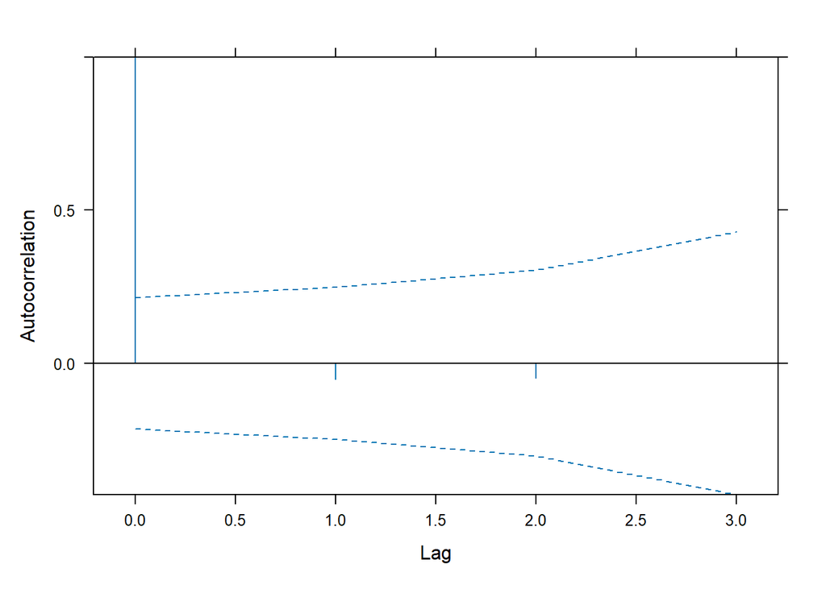

```r
ACF(mod2_cs, resType = "n") %>%
  plot(alpha = 0.01)
```

```r
intervals(mod2_cs,which = "var-cov")
```

```
Approximate 95% confidence intervals

 Random Effects:
  Level: block
                   lower     est.    upper
sd((Intercept)) 31.51816 216.6994 1489.891
  Level: krate_kgha
                  lower     est.    upper
sd((Intercept)) 45.5682 249.4048 1365.047
  Level: nrate_kgha
                   lower     est.   upper
sd((Intercept)) 419.7116 581.9092 806.788

 Correlation structure:
         lower      est. upper
Rho -0.3333333 0.1150903     1

 Within-group standard error:
       lower         est.        upper
2.386519e-02 1.549514e+01 1.006065e+04
```

```r
anova(mod1_default,
      mod2_cs)
```

```
             Model df      AIC      BIC    logLik   Test      L.Ratio p-value
mod1_default     1 40 1335.083 1442.369 -627.5418
mod2_cs          2 41 1337.083 1447.051 -627.5418 1 vs 2 3.230298e-09       1
```

# 5 Questions

In class, we decided to use AIC as the metric to select the best model, and this determined the best model to be the one with a general error correlation matrix structure. If we had used BIC as the metric, then the model selected would have been the default model. Here, you are asked to use BIC and thus select the default model as the best, and perform all the steps after model selection. You may copy and paste the class script, and adapt the copied version to implement these changes.

## 5.1 Q1: Include here the residual assessment of the default model. Include each plot and its interpretation. How do these residuals from the default model visually compare to those from the general model?

```r
mod1_default <-lme(yield_kgha ~krate_kgha*nrate_kgha*fdap,
                   random = ~1 |block/krate_kgha/nrate_kgha,
                   data = rm_rcbd_df
                   )


mod1_default
```

```
Linear mixed-effects model fit by REML
  Data: rm_rcbd_df
  Log-restricted-likelihood: -627.5418
  Fixed: yield_kgha ~ krate_kgha * nrate_kgha * fdap
                  (Intercept)                   krate_kgha1
                5233.48611111                 -125.27777778
                  krate_kgha2                   nrate_kgha1
                 -27.77777778                  286.53472222
                  nrate_kgha2                         fdap1
                -189.65277778                 -412.15277778
                        fdap2                         fdap3
                 -12.76388889                  186.76388889
      krate_kgha1:nrate_kgha1       krate_kgha2:nrate_kgha1
                 165.06944444                 -873.86805556
      krate_kgha1:nrate_kgha2       krate_kgha2:nrate_kgha2
                -566.24305556                  469.00694444
            krate_kgha1:fdap1             krate_kgha2:fdap1
                   0.36111111                    1.36111111
            krate_kgha1:fdap2             krate_kgha2:fdap2
                  -3.44444444                   -1.11111111
            krate_kgha1:fdap3             krate_kgha2:fdap3
                  -0.88888889                    1.61111111
            nrate_kgha1:fdap1             nrate_kgha2:fdap1
                  -3.61805556                    2.40277778
            nrate_kgha1:fdap2             nrate_kgha2:fdap2
                   1.65972222                   -0.06944444
            nrate_kgha1:fdap3             nrate_kgha2:fdap3
                   3.21527778                   -3.93055556
krate_kgha1:nrate_kgha1:fdap1 krate_kgha2:nrate_kgha1:fdap1
                  -0.40277778                    6.28472222
krate_kgha1:nrate_kgha2:fdap1 krate_kgha2:nrate_kgha2:fdap1
                   3.07638889                   -2.42361111
krate_kgha1:nrate_kgha1:fdap2 krate_kgha2:nrate_kgha1:fdap2
                   3.48611111                  -14.15972222
krate_kgha1:nrate_kgha2:fdap2 krate_kgha2:nrate_kgha2:fdap2
                  -7.53472222                    7.38194444
krate_kgha1:nrate_kgha1:fdap3 krate_kgha2:nrate_kgha1:fdap3
                   1.59722222                   -2.21527778
krate_kgha1:nrate_kgha2:fdap3 krate_kgha2:nrate_kgha2:fdap3
                  -1.25694444                    2.49305556

Random effects:
 Formula: ~1 | block
        (Intercept)
StdDev:    216.6936

 Formula: ~1 | krate_kgha %in% block
        (Intercept)
StdDev:    249.3989

 Formula: ~1 | nrate_kgha %in% krate_kgha %in% block
        (Intercept) Residual
StdDev:    581.9363 14.57621

Number of Observations: 144
Number of Groups:
                                block                 krate_kgha %in% block
                                    4                                    12
nrate_kgha %in% krate_kgha %in% block
                                   36
```

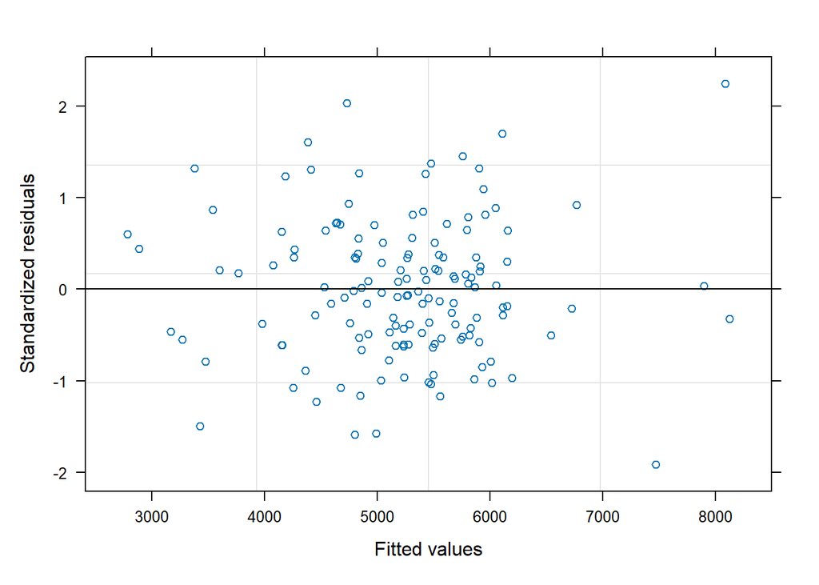

```r
par(mfrow = c(2, 2))
plot(mod1_default, which = 1)  # Residuals vs Fitted
```

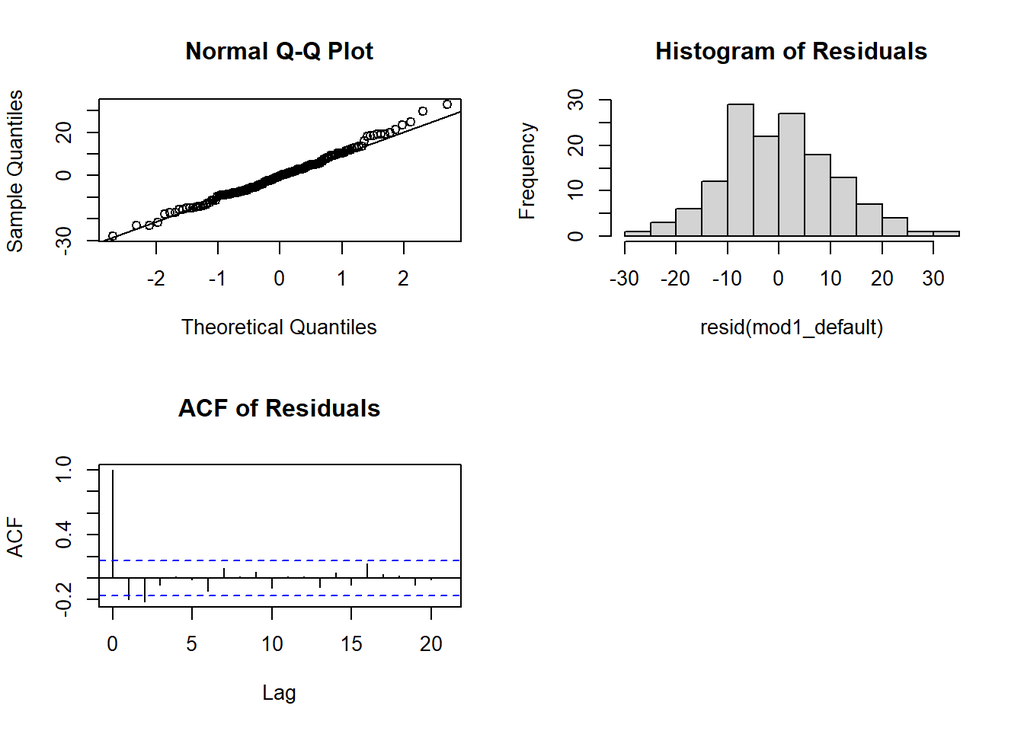

```r
qqnorm(resid(mod1_default)); qqline(resid(mod1_default))  # Normality check

hist(resid(mod1_default), main = "Histogram of Residuals")

acf(resid(mod1_default), main = "ACF of Residuals")
```

## 5.2 Q2: Include here the ANOVA table from the default model. How does it compare with the ANOVA table from the general model?

```r
anova(mod1_default)
```

```
                           numDF denDF   F-value p-value
(Intercept)                    1    81  1040.205  <.0001
krate_kgha                     2     6     0.456  0.6543
nrate_kgha                     2    18     2.258  0.1334
fdap                           3    81 14776.785  <.0001
krate_kgha:nrate_kgha          4    18     8.320  0.0006
krate_kgha:fdap                6    81     0.625  0.7097
nrate_kgha:fdap                6    81     0.529  0.7849
krate_kgha:nrate_kgha:fdap    12    81     1.656  0.0926
```

# 6 Submitting your work

Once you have developed all the code and answers, make sure to Render this quarto file.

**Notes on rendering**:

- Make sure to render your work and inspect how the final html look like.
- If it does not look professional for whatever reason, then fix the issue, re-render it, recheck.
- Only send me your work once your html file looks professional.
  - **DO NOT** delete the file’s heading levels (# and ##). They set up the proper heading 1 and 2 levels, and I use them to guide my grading.
  - If a given chunk is also outputting warnings or messages, inhibit this behavior by changing the chunk options `message` and `warning` to `FALSE` (I’ll demo this in a moment).
  - If, after rendered, 2 lines of text are connected and you wish to “break line” between them, add 2 extra spaces after the first one (I’lld demo this in a moment).

After rendering, an .html file will be created on your `code` folder.

Rename this file to `Assignment-07-rm-LASTNAME.html`.

For ex., mine would be `Assignment-07-rm-Bastos.html`.

Submit your work by uploading the **html** file to **eLC Assigment #7 - Repeated measure** by Mar 25 11:59 pm.